# **Problem Statement**

## Business Context

Renewable energy sources play an increasingly important role in the global energy mix, as the effort to reduce the environmental impact of energy production increases.

Out of all the renewable energy alternatives, wind energy is one of the most developed technologies worldwide. The U.S Department of Energy has put together a guide to achieving operational efficiency using predictive maintenance practices.

Predictive maintenance uses sensor information and analysis methods to measure and predict degradation and future component capability. The idea behind predictive maintenance is that failure patterns are predictable and if component failure can be predicted accurately and the component is replaced before it fails, the costs of operation and maintenance will be much lower.

The sensors fitted across different machines involved in the process of energy generation collect data related to various environmental factors (temperature, humidity, wind speed, etc.) and additional features related to various parts of the wind turbine (gearbox, tower, blades, break, etc.).

## Objective

“ReneWind” is a company working on improving the machinery/processes involved in the production of wind energy using machine learning and has collected data of generator failure of wind turbines using sensors. They have shared a ciphered version of the data, as the data collected through sensors is confidential (the type of data collected varies with companies). Data has 40 predictors, 20000 observations in the training set and 5000 in the test set.

The objective is to build various classification models, tune them, and find the best one that will help identify failures so that the generators could be repaired before failing/breaking to reduce the overall maintenance cost. The nature of predictions made by the classification model will translate as follows:

- True positives (TP) are failures correctly predicted by the model. These will result in repairing costs.
- False negatives (FN) are real failures where there is no detection by the model. These will result in replacement costs.
- False positives (FP) are detections where there is no failure. These will result in inspection costs.

It is given that the cost of repairing a generator is much less than the cost of replacing it, and the cost of inspection is less than the cost of repair.

“1” in the target variables should be considered as “failure” and “0” represents “No failure”.

## Data Description

The data provided is a transformed version of the original data which was collected using sensors.

- Train.csv - To be used for training and tuning of models.
- Test.csv - To be used only for testing the performance of the final best model.

Both the datasets consist of 40 predictor variables and 1 target variable.

## **Executive Summary**

We build a cost-sensitive classifier to predict wind-turbine generator failures (`1 = failure, 0 = no failure`) from 40 anonymized sensor-derived predictors.

The notebook enforces **no data leakage** via scikit‑learn `Pipelines` and selects a decision **threshold** to **minimize expected business cost** (FN ≫ TP ≫ FP ≫ TN=0).

These are the techniques and knowledge considered for the project:

- SGD and Adam are standard optimizers for deep neural nets
- unequal misclassification costs require cost‑sensitive thresholds.
- PR‑AUC is more informative than ROC‑AUC under class imbalance.
- caution that modern nets can be miscalibrated and benefit from post‑hoc scaling.

# **Installing and Importing the necessary libraries**

```python
# Installing the libraries with the specified version
!pip install --no-deps tensorflow==2.18.0 scikit-learn==1.3.2 matplotlib===3.8.3 seaborn==0.13.2 numpy==1.26.4 pandas==2.2.2 -q --user --no-warn-script-location
```

```python
import os, random, math, warnings, sys, json, textwrap
import numpy as np
import pandas as pd
import matplotlib.pyplot as plt
import seaborn as sns

import sklearn
from sklearn.model_selection import train_test_split
from sklearn.preprocessing import StandardScaler
from sklearn.compose import ColumnTransformer
from sklearn.pipeline import Pipeline
from sklearn.metrics import (roc_auc_score, average_precision_score,
                             precision_recall_curve, roc_curve,
                             confusion_matrix, precision_score, recall_score,
                             f1_score)
from sklearn.utils.class_weight import compute_class_weight
from sklearn.feature_selection import mutual_info_classif
from sklearn.metrics import confusion_matrix, ConfusionMatrixDisplay
import matplotlib.pyplot as plt
from sklearn.impute import SimpleImputer

import tensorflow as tf
from tensorflow import keras
from tensorflow.keras import layers, callbacks, optimizers
from google.colab import drive

# import deepcopy
from copy import deepcopy

warnings.filterwarnings("ignore")

# Reproducibility
PY_SEED = 67
random.seed(PY_SEED)
np.random.seed(PY_SEED)
tf.keras.utils.set_random_seed(PY_SEED)
tf.random.set_seed(PY_SEED)
try:
    tf.config.experimental.enable_op_determinism()
except Exception:
    pass

# Print versions
print({
    "python": sys.version.split()[0],
    "tensorflow": tf.__version__,
    "sklearn": sklearn.__version__,
    "numpy": np.__version__,
    "pandas": pd.__version__,
    "matplotlib": plt.matplotlib.__version__,
    "seaborn": sns.__version__,
})
```

```
{'python': '3.12.11', 'tensorflow': '2.18.0', 'sklearn': '1.3.2', 'numpy': '1.26.4', 'pandas': '2.2.2', 'matplotlib': '3.8.3', 'seaborn': '0.13.2'}
```

**Note**:

- After running the above cell, kindly restart the runtime (for Google Colab) or notebook kernel (for Jupyter Notebook), and run all cells sequentially from the next cell.
- On executing the above line of code, you might see a warning regarding package dependencies. This error message can be ignored as the above code ensures that all necessary libraries and their dependencies are maintained to successfully execute the code in **this notebook**.

# **Loading the Data**

```python
# uncomment and run the following lines for Google Colab
drive.mount('/content/drive')
```

```python
# load data from train.csv and test.csv from google drive
train_df = pd.read_csv('/content/drive/My Drive/Colab/NN Proj/Train.csv')
test_df = pd.read_csv('/content/drive/My Drive/Colab/NN Proj/Test.csv')
```

# **Data Overview**

```python
print("Train shape:", train_df.shape)
print("Test shape:", test_df.shape)

TARGET_COL = "Target"
assert TARGET_COL in train_df.columns, f"'{TARGET_COL}' not found in Train.csv columns"

X = train_df.drop(columns=[TARGET_COL])
y = train_df[TARGET_COL].astype(int)

X_test = test_df.copy()

print("\nDtypes (train):")
print(train_df.dtypes.value_counts())
print("\nHead:")
display(train_df.head())

# Target prevalence
pos_rate = y.mean()
print(f"\nTarget prevalence (class=1): {pos_rate:.3%}")
```

```
Train shape: (20000, 41)
Test shape: (5000, 41)

Dtypes (train):
float64    40
int64       1
Name: count, dtype: int64

Head:
```

|  | V1 | V2 | V3 | V4 | V5 | V6 | V7 | V8 | V9 | V10 | ... | V32 | V33 | V34 | V35 | V36 | V37 | V38 | V39 | V40 | Target |
| --- | --- | --- | --- | --- | --- | --- | --- | --- | --- | --- | --- | --- | --- | --- | --- | --- | --- | --- | --- | --- | --- |
| 0 | -4.464606 | -4.679129 | 3.101546 | 0.506130 | -0.221083 | -2.032511 | -2.910870 | 0.050714 | -1.522351 | 3.761892 | ... | 3.059700 | -1.690440 | 2.846296 | 2.235198 | 6.667486 | 0.443809 | -2.369169 | 2.950578 | -3.480324 | 0 |
| 1 | 3.365912 | 3.653381 | 0.909671 | -1.367528 | 0.332016 | 2.358938 | 0.732600 | -4.332135 | 0.565695 | -0.101080 | ... | -1.795474 | 3.032780 | -2.467514 | 1.894599 | -2.297780 | -1.731048 | 5.908837 | -0.386345 | 0.616242 | 0 |
| 2 | -3.831843 | -5.824444 | 0.634031 | -2.418815 | -1.773827 | 1.016824 | -2.098941 | -3.173204 | -2.081860 | 5.392621 | ... | -0.257101 | 0.803550 | 4.086219 | 2.292138 | 5.360850 | 0.351993 | 2.940021 | 3.839160 | -4.309402 | 0 |
| 3 | 1.618098 | 1.888342 | 7.046143 | -1.147285 | 0.083080 | -1.529780 | 0.207309 | -2.493629 | 0.344926 | 2.118578 | ... | -3.584425 | -2.577474 | 1.363769 | 0.622714 | 5.550100 | -1.526796 | 0.138853 | 3.101430 | -1.277378 | 0 |
| 4 | -0.111440 | 3.872488 | -3.758361 | -2.982897 | 3.792714 | 0.544960 | 0.205433 | 4.848994 | -1.854920 | -6.220023 | ... | 8.265896 | 6.629213 | -10.068689 | 1.222987 | -3.229763 | 1.686909 | -2.163896 | -3.644622 | 6.510338 | 0 |

5 rows × 41 columns

```
Target prevalence (class=1): 5.550%
```

```python
# Missing values table
missing = train_df.isna().mean().sort_values(ascending=False)
display(pd.DataFrame({"missing_rate": missing[missing>0]}))

# Constant / near-constant
nunique = X.nunique()
const_cols = nunique[nunique <= 1].index.tolist()
if const_cols:
    print("Constant features:", const_cols)
else:
    print("No constant features detected.")
```

|  | missing_rate |
| --- | --- |
| V1 | 0.0009 |
| V2 | 0.0009 |

```
No constant features detected.
```

# **Exploratory Data Analysis**

## Univariate analysis

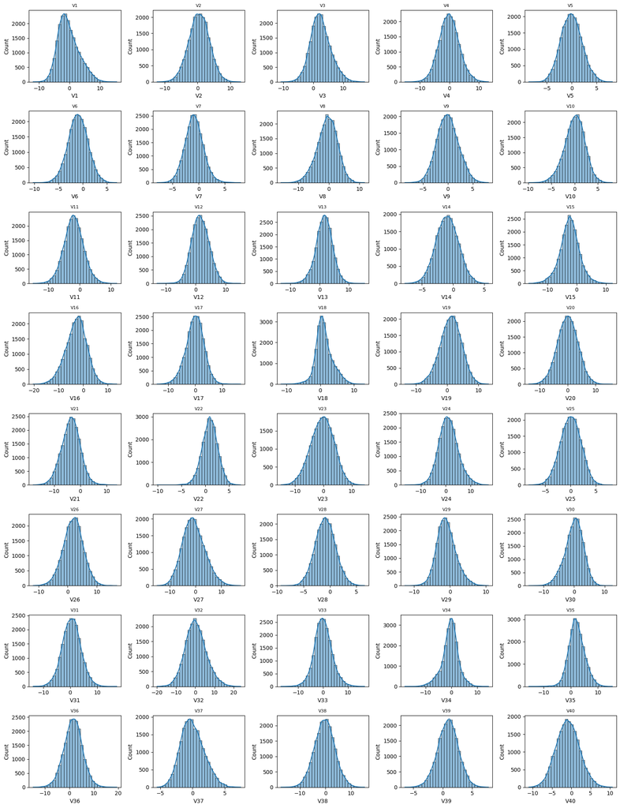

```python
num_cols = X.select_dtypes(include=[np.number]).columns.tolist()
n = len(num_cols)
cols = 5
rows = int(np.ceil(n / cols))
fig, axes = plt.subplots(rows, cols, figsize=(cols*3.2, rows*2.6))
axes = axes.flatten()
for i, col in enumerate(num_cols):
    ax = axes[i]
    sns.histplot(X[col], kde=True, ax=ax, bins=30)
    ax.set_title(col, fontsize=8)
for j in range(i+1, len(axes)):
    axes[j].axis("off")
plt.tight_layout()
plt.show()
```

## Key takeaways (Univariate):

- All 40 features are continuous and roughly bell-shaped, centered near zero. This shows that the data is in ciphered form and are in abstract forms.
- No features are constant or flat — every variable shows variability and can contribute signal to the model.
- Some features show slightly wider ranges (up to +/-20) or sharper peaks, but overall there are no severe skews or distributions.
- Implication: further transformations aren’t needed, but consistent scaling via StandardScaler may still be important before training neural networks.

## Bivariate Analysis

### **Why we used Spearman, MI, and class-wise density plots instead of scatterplots**

Because the dataset has 40 anonymized continuous features, most of the predictive signal is not in simple 2-D plots but in **higher-dimensional combinations of features**. A scatterplot of any two variables would mostly show overlap between failure and non-failure cases.

To uncover relationships that might still matter:

- We used **Spearman correlation** to capture monotonic (up or down) relationships with the target.
- We used **mutual information** to detect nonlinear associations that correlation can miss.
- We then used **class-wise density plots** to visualize how the distributions of the most informative features differ between failures and non-failures.

This combination provides clearer evidence of which features carry predictive signal without overwhelming us with uninterpretable scatter clouds.

```python
# Spearman correlations with target (numeric proxy)
spearman_corrs = {}
for col in num_cols:
    spearman_corrs[col] = X[col].corr(y, method="spearman")
spearman_s = pd.Series(spearman_corrs).sort_values(key=lambda s: s.abs(), ascending=False)
display(spearman_s.to_frame("spearman_with_target").head(15))
```

|  | spearman_with_target |
| --- | --- |
| V18 | -0.235435 |
| V36 | -0.231285 |
| V15 | 0.214809 |
| V39 | -0.214442 |
| V16 | 0.213247 |
| V21 | 0.211885 |
| V3 | -0.200833 |
| V7 | 0.189398 |
| V28 | 0.189371 |
| V26 | -0.175615 |
| V11 | 0.175189 |
| V34 | 0.146190 |
| V8 | 0.137249 |
| V31 | -0.126074 |
| V4 | 0.118893 |

```python
# Mutual information (nonlinear associations)
mi = mutual_info_classif(X[num_cols].fillna(X[num_cols].median()), y, random_state=PY_SEED)
mi_s = pd.Series(mi, index=num_cols).sort_values(ascending=False)
display(mi_s.to_frame("mutual_information").head(15))
```

|  | mutual_information |
| --- | --- |
| V18 | 0.053122 |
| V21 | 0.037595 |
| V15 | 0.034197 |
| V36 | 0.033170 |
| V7 | 0.033116 |
| V16 | 0.028360 |
| V39 | 0.026356 |
| V3 | 0.026058 |
| V35 | 0.024558 |
| V11 | 0.022936 |
| V28 | 0.021281 |
| V26 | 0.018116 |
| V13 | 0.016351 |
| V22 | 0.014360 |
| V12 | 0.014081 |

**Key takeaways (Bivariate Analysis - Spearman and MI):**

- Both Spearman correlation and mutual information highlight a small group of features (V18, V36, V15, V21, V39, V16) as the most informative for predicting failures.
- Negative correlations (e.g., V18, V36, V39) mean that higher feature values are linked with fewer failures; positive correlations (e.g., V15, V16, V21) mean the opposite.

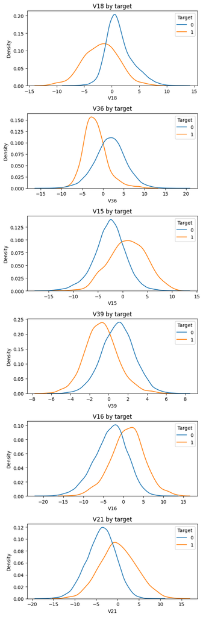

```python
# Class-wise distributions for top few features
top_feats = spearman_s.index[:6].tolist()
fig, axes = plt.subplots(len(top_feats), 1, figsize=(6, 3*len(top_feats)))
if len(top_feats) == 1:
    axes = [axes]
for i, col in enumerate(top_feats):
    ax = axes[i]
    sns.kdeplot(data=train_df, x=col, hue=TARGET_COL, common_norm=False, ax=ax)
    ax.set_title(f"{col} by target")
plt.tight_layout()
plt.show()
```

**Key takeaways (Bivariate Analysis - Class-wise density plots):**

- Class-wise density plots show visible shifts between “failure” and “no failure” distributions for these features, confirming that they carry predictive signal.
- The overlap between the curves shows that no single feature can perfectly separate the classes; predictive power will come from combining many features in a model.
- Since the features are anonymized, we can’t interpret them physically, but statistically they provide enough separation to support a classification approach.

# **Data Preprocessing**

```python
# Stratified split
X_train, X_valid, y_train, y_valid = train_test_split(
    X, y, test_size=0.2, stratify=y, random_state=PY_SEED
)
print("Train:", X_train.shape, "Valid:", X_valid.shape)

# Numeric pipeline (median impute + scale)
numeric_transformer = Pipeline(steps=[
    ("imputer", SimpleImputer(strategy="median")),
    ("scaler", StandardScaler())
])

preprocess = ColumnTransformer(
    transformers=[("num", numeric_transformer, num_cols)],
    remainder="drop"
)

preprocess.fit(X_train)
X_train_proc = preprocess.transform(X_train)
X_valid_proc   = preprocess.transform(X_valid)

# Class weights from training prevalence
classes = np.array([0,1])
class_weights_arr = compute_class_weight(
    class_weight="balanced", classes=classes, y=y_train
)
CLASS_WEIGHT = {int(c): w for c, w in zip(classes, class_weights_arr)}
CLASS_WEIGHT
```

```
Train: (16000, 40) Valid: (4000, 40)
```

```
{0: 0.5293806246691372, 1: 9.00900900900901}
```

# **Model Building**

```python
# ---- Business costs (set per business; keep FP < TP < FN) ----
C_TN = 0.0
C_FP = 1.0     # inspection (lowest)
C_TP = 5.0     # repair (middle)
C_FN = 20.0    # replacement (highest)

def expected_cost_from_counts(tp, fn, fp, tn):
    return tp*C_TP + fn*C_FN + fp*C_FP + tn*C_TN

def confusion_counts_at_threshold(y_true, y_prob, t=0.5):
    y_pred = (y_prob >= t).astype(int)
    tn, fp, fn, tp = confusion_matrix(y_true, y_pred, labels=[0,1]).ravel()
    return tp, fn, fp, tn

def eval_at_threshold(y_true, y_prob, t):
    tp, fn, fp, tn = confusion_counts_at_threshold(y_true, y_prob, t)
    prec = precision_score(y_true, (y_prob>=t).astype(int), zero_division=0)
    rec  = recall_score(y_true, (y_prob>=t).astype(int), zero_division=0)
    f1   = f1_score(y_true, (y_prob>=t).astype(int), zero_division=0)
    beta = 2.0
    if prec+rec == 0:
        fbeta = 0.0
    else:
        fbeta = (1+beta**2) * (prec*rec) / (beta**2*prec + rec + 1e-12)
    cost = expected_cost_from_counts(tp, fn, fp, tn)
    return {
        "threshold": t, "precision": prec, "recall": rec, "f1": f1, "f2": fbeta,
        "tp": tp, "fn": fn, "fp": fp, "tn": tn, "expected_cost": cost
    }

def search_cost_optimal_threshold(y_true, y_prob, tie_break="recall_then_prauc", n_grid=200):
    # grid on unique probabilities + linspace for stability
    uniq = np.unique(y_prob)
    grid = np.unique(np.concatenate([np.linspace(0,1,n_grid), uniq]))
    best = None
    for t in grid:
        r = eval_at_threshold(y_true, y_prob, t)
        if best is None or r["expected_cost"] < best["expected_cost"] - 1e-9:
            best = r
        elif abs(r["expected_cost"] - best["expected_cost"]) <= 1e-9:
            # tie-breaker: higher recall, then higher precision
            if r["recall"] > best["recall"] + 1e-12 or (
                abs(r["recall"] - best["recall"]) <= 1e-12 and r["precision"] > best["precision"] + 1e-12
            ):
                best = r
    return best

def summarize_probs(y_true, y_prob):
    return {
        "roc_auc": roc_auc_score(y_true, y_prob),
        "pr_auc":  average_precision_score(y_true, y_prob)
    }
```

## Model Evaluation Criterion

Write down the model evaluation criterion with rationale

### Metric Choice and Rationale

In settings where **false negatives are much more expensive** than repairs or inspections, the decision rule should **shift the threshold** to reduce FN.

Cost‑sensitive thresholding is standard. Because the positive class is likely minority, **PR‑AUC** is emphasized alongside ROC‑AUC. Class weights and calibration are appropriate under imbalance and probability miscalibration.

```python
# Check for GPU and set policy
try:
    physical_devices = tf.config.list_physical_devices('GPU')
    if len(physical_devices) > 0:
        tf.config.set_visible_devices(physical_devices[0], 'GPU')
        tf.config.experimental.set_memory_growth(physical_devices[0], True)
        print("GPU found and configured:", physical_devices[0])
    else:
        print("No GPU found. Using CPU.")
except:
    print("Error configuring GPU. Using CPU.")


def build_model(input_dim: int,
                hidden_layers=(32,),
                dropout=None,
                optimizer="sgd",
                lr=1e-2,
                momentum=0.9,
                l2=0.0):
    # Use GPU if available
    with tf.device('/GPU:0' if tf.config.list_physical_devices('GPU') else '/CPU:0'):
        model = keras.Sequential(name="nn_clf")
        model.add(layers.Input(shape=(input_dim,)))
        for units in hidden_layers:
            model.add(layers.Dense(units, activation="relu",
                                   kernel_regularizer=keras.regularizers.l2(l2) if l2>0 else None))
            if dropout:
                model.add(layers.Dropout(dropout))
        model.add(layers.Dense(1, activation="sigmoid"))

        if optimizer.lower() == "adam":
            opt = optimizers.Adam(learning_rate=lr)
        elif optimizer.lower() == "rmsprop":
            opt = optimizers.RMSprop(learning_rate=lr)
        else:
            opt = optimizers.SGD(learning_rate=lr, momentum=momentum, nesterov=True)

        model.compile(
            optimizer=opt,
            loss="binary_crossentropy",
            metrics=[
                keras.metrics.AUC(name="roc_auc", curve="ROC"),
                keras.metrics.AUC(name="pr_auc",  curve="PR"),
                keras.metrics.Precision(name="precision"),
                keras.metrics.Recall(name="recall"),
            ],
        )
    return model

def train_and_evaluate(model_name, model_kwargs, use_class_weights=False, verbose=0):
    input_dim = X_train_proc.shape[1]
    model = build_model(input_dim=input_dim, **model_kwargs)

    es   = callbacks.EarlyStopping(monitor="val_pr_auc", mode="max", patience=10, restore_best_weights=True)
    rlrp = callbacks.ReduceLROnPlateau(monitor="val_pr_auc", mode="max", patience=5, factor=0.5, min_lr=1e-5)

    fit_kwargs = dict(
        x=X_train_proc, y=y_train, epochs=200, batch_size=256,
        validation_data=(X_valid_proc, y_valid),
        callbacks=[es, rlrp], verbose=verbose,
    )
    if use_class_weights:
        fit_kwargs["class_weight"] = CLASS_WEIGHT

    hist = model.fit(**fit_kwargs)
    y_valid_prob = model.predict(X_valid_proc, verbose=0).ravel()

    curves = summarize_probs(y_valid, y_valid_prob)  # ROC & PR AUC from sklearn
    opt    = search_cost_optimal_threshold(y_valid, y_valid_prob)

    tn, fp, fn, tp = confusion_matrix(y_valid, (y_valid_prob>=opt["threshold"]).astype(int), labels=[0,1]).ravel()
    return model, {
        "model_name": model_name,
        "params": {**model_kwargs, "use_class_weights": use_class_weights},
        "history": {k: [float(x) for x in v] for k, v in hist.history.items()},
        "valid_probs": y_valid_prob.tolist(),
        "roc_auc": float(curves["roc_auc"]),
        "pr_auc":  float(curves["pr_auc"]),
        "opt_threshold": float(opt["threshold"]),
        "recall_at_t": float(opt["recall"]),
        "precision_at_t": float(opt["precision"]),
        "f2_at_t": float(opt["f2"]),
        "expected_cost_at_t": float(opt["expected_cost"]),
        "confusion_at_t": {"tn": int(tn), "fp": int(fp), "fn": int(fn), "tp": int(tp)},
        "keras_params_count": int(model.count_params()),
    }

def summarize_probs(y_true, y_prob):
    return {
        "roc_auc": roc_auc_score(y_true, y_prob),
        "pr_auc":  average_precision_score(y_true, y_prob)
    }

def expected_cost_from_counts(tp, fn, fp, tn):
    return tp*C_TP + fn*C_FN + fp*C_FP + tn*C_TN

def confusion_counts_at_threshold(y_true, y_prob, t=0.5):
    y_pred = (y_prob >= t).astype(int)
    tn, fp, fn, tp = confusion_matrix(y_true, y_pred, labels=[0,1]).ravel()
    return tp, fn, fp, tn

def eval_at_threshold(y_true, y_prob, t):
    tp, fn, fp, tn = confusion_counts_at_threshold(y_true, y_prob, t)
    prec = precision_score(y_true, (y_prob>=t).astype(int), zero_division=0)
    rec  = recall_score(y_true, (y_prob>=t).astype(int), zero_division=0)
    f1   = f1_score(y_true, (y_prob>=t).astype(int), zero_division=0)
    beta = 2.0
    if prec+rec == 0:
        fbeta = 0.0
    else:
        fbeta = (1+beta**2) * (prec*rec) / (beta**2*prec + rec + 1e-12)
    cost = expected_cost_from_counts(tp, fn, fp, tn)
    return {
        "threshold": t, "precision": prec, "recall": rec, "f1": f1, "f2": fbeta,
        "tp": tp, "fn": fn, "fp": fp, "tn": tn, "expected_cost": cost
    }

def search_cost_optimal_threshold(y_true, y_prob, tie_break="recall_then_prauc", n_grid=200):
    # grid on unique probabilities + linspace for stability
    uniq = np.unique(y_prob)
    grid = np.unique(np.concatenate([np.linspace(0,1,n_grid), uniq]))
    best = None
    for t in grid:
        r = eval_at_threshold(y_true, y_prob, t)
        if best is None or r["expected_cost"] < best["expected_cost"] - 1e-9:
            best = r
        elif abs(r["expected_cost"] - best["expected_cost"]) <= 1e-9:
            # tie-breaker: higher recall, then higher precision
            if r["recall"] > best["recall"] + 1e-12 or (
                abs(r["recall"] - best["recall"]) <= 1e-12 and r["precision"] > best["precision"] + 1e-12
            ):
                best = r
    return best
```

```
GPU found and configured: PhysicalDevice(name='/physical_device:GPU:0', device_type='GPU')
```

## Initial Model Building (Model 0)

- Let's start with a neural network consisting of
  - just one hidden layer
  - activation function of ReLU
  - SGD as the optimizer

```
ROC-AUC: 0.9578510485074805 PR-AUC: 0.9122629906847687
Opt threshold: 0.09211450070142746
Recall@t: 0.8963963963963963 Precision@t: 0.796 F2@t: 0.8743409490331774
Expected Cost@t: 1506.0
Confusion@t: {'tn': 3727, 'fp': 51, 'fn': 23, 'tp': 199}
```

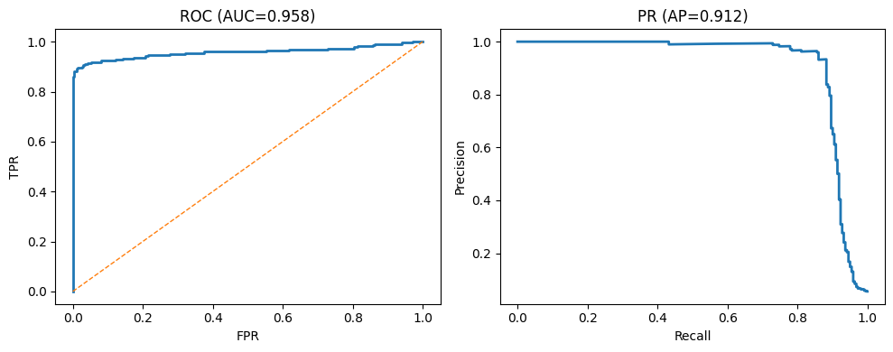

```python
model0_kwargs = dict(hidden_lasyers=(32,), dropout=None, optimizer="sgd", lr=1e-2, momentum=0.9, l2=0.0)
model0, res0 = train_and_evaluate("Model 0 — SGD(32)", model0_kwargs, use_class_weights=False, verbose=0)

print("ROC-AUC:", res0["roc_auc"], "PR-AUC:", res0["pr_auc"])
print("Opt threshold:", res0["opt_threshold"])
print("Recall@t:", res0["recall_at_t"], "Precision@t:", res0["precision_at_t"], "F2@t:", res0["f2_at_t"])
print("Expected Cost@t:", res0["expected_cost_at_t"])
print("Confusion@t:", res0["confusion_at_t"])

# ROC & PR curves
yvp = np.array(res0["valid_probs"])
fpr, tpr, _ = roc_curve(y_valid, yvp)
prec, rec, _ = precision_recall_curve(y_valid, yvp)

fig = plt.figure(figsize=(10,4))
plt.subplot(1,2,1)
plt.plot(fpr, tpr, lw=2); plt.plot([0,1],[0,1],'--', lw=1)
plt.xlabel("FPR"); plt.ylabel("TPR"); plt.title(f"ROC (AUC={res0['roc_auc']:.3f})")

plt.subplot(1,2,2)
plt.plot(rec, prec, lw=2)
plt.xlabel("Recall"); plt.ylabel("Precision"); plt.title(f"PR (AP={res0['pr_auc']:.3f})")
plt.tight_layout(); plt.show()
```

### Model 0 — Baseline SGD (32)

- auc values strong roc ~0.958 pr ~0.912
- recall ~89.6% precision ~79.6%
- threshold ~0.09 leads to lots of extra positives
- cost ~1506 worse than optimized variants
- still important anchor model

Overall

This is a conservative model, when it says failure it’s usually right but it misses a few more failures than we want so we can try to improve it here.

# **Models 1–6 — Performance Improvement**

```python
all_results = [res0]
trained = {"Model 0 — SGD(32)": model0}

def add_model(name, kw, use_cw=False, verbose=0):
    m, r = train_and_evaluate(name, kw, use_class_weights=use_cw, verbose=verbose)
    trained[name] = m
    all_results.append(r)
    display(pd.DataFrame([{
        "Model": r["model_name"],
        "Val ROC-AUC": r["roc_auc"],
        "Val PR-AUC": r["pr_auc"],
        "t*": r["opt_threshold"],
        "Recall@t*": r["recall_at_t"],
        "Precision@t*": r["precision_at_t"],
        "F2@t*": r["f2_at_t"],
        "Expected Cost@t*": r["expected_cost_at_t"],
        "Params": r["keras_params_count"],
    }]))

    # Confusion matrix with percentages
    y_true = y_valid
    y_pred = (np.array(r["valid_probs"]) >= r["opt_threshold"]).astype(int)
    cm = confusion_matrix(y_true, y_pred, labels=[0,1])
    cm_sum = cm.sum()
    cm_perc = cm / cm_sum * 100

    fig, ax = plt.subplots(figsize=(4,4))
    im = ax.imshow(cm, interpolation='nearest', cmap="Blues")

    classes = ["No Failure (0)", "Failure (1)"]
    ax.set(
        xticks=np.arange(cm.shape[1]),
        yticks=np.arange(cm.shape[0]),
        xticklabels=classes, yticklabels=classes,
        ylabel="True label",
        xlabel="Predicted label",
        title=f"Confusion Matrix with % — {name}"
    )
    plt.setp(ax.get_xticklabels(), rotation=45, ha="right", rotation_mode="anchor")

    # Annotate counts and percentages
    thresh = cm.max() / 2.
    for i in range(cm.shape[0]):
        for j in range(cm.shape[1]):
            ax.text(j, i,
                    f"{cm[i, j]}\n({cm_perc[i, j]:.1f}%)",
                    ha="center", va="center",
                    color="white" if cm[i, j] > thresh else "black")

    fig.tight_layout()
    plt.show()
```

|  | Model | Val ROC-AUC | Val PR-AUC | t* | Recall@t* | Precision@t* | F2@t* | Expected Cost@t* | Params |
| --- | --- | --- | --- | --- | --- | --- | --- | --- | --- |
| 0 | Model 1 — Deeper SGD(64,32) | 0.9563 | 0.908015 | 0.085427 | 0.891892 | 0.773438 | 0.865385 | 1528.0 | 4737 |

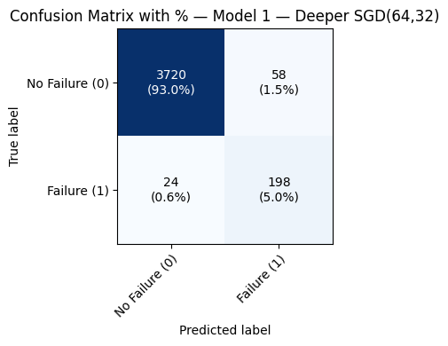

```python
add_model("Model 1 — Deeper SGD(64,32)",
        dict(hidden_layers=(64,32), dropout=None, optimizer="sgd", lr=1e-2, momentum=0.9, l2=0.0))
```

### Model 1 — Deeper SGD (64,32)

|  | Model | Val ROC-AUC | Val PR-AUC | t* | Recall@t* | Precision@t* | F2@t* | Expected Cost@t* | Params |
| --- | --- | --- | --- | --- | --- | --- | --- | --- | --- |
| 0 | Model 2 — Baseline+Adam(32) | 0.951583 | 0.908589 | 0.142716 | 0.896396 | 0.876652 | 0.892377 | 1483.0 | 1345 |

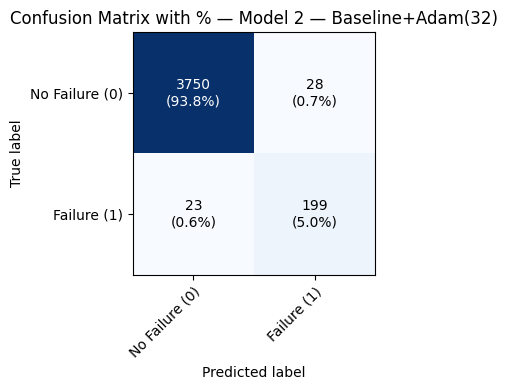

```python
add_model("Model 2 — Baseline+Adam(32)",
        dict(hidden_layers=(32,), dropout=None, optimizer="adam", lr=1e-3, momentum=0.0, l2=0.0))
```

### Model 2 — Baseline + Adam (32)

|  | Model | Val ROC-AUC | Val PR-AUC | t* | Recall@t* | Precision@t* | F2@t* | Expected Cost@t* | Params |
| --- | --- | --- | --- | --- | --- | --- | --- | --- | --- |
| 0 | Model 3 — Deep+Dropout(0.3) SGD | 0.953922 | 0.905462 | 0.057961 | 0.896396 | 0.789683 | 0.872807 | 1508.0 | 4737 |

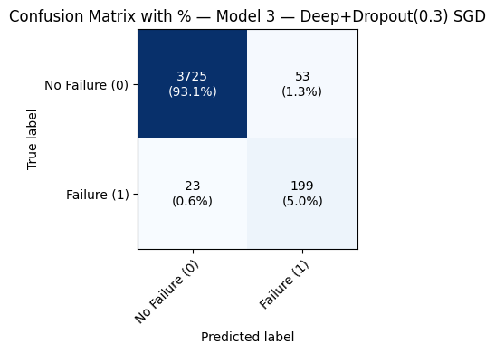

```python
add_model("Model 3 — Deep+Dropout(0.3) SGD",
        dict(hidden_layers=(64,32), dropout=0.3, optimizer="sgd", lr=1e-2, momentum=0.9, l2=0.0))
```

### Model 3 — Deep + Dropout(0.3) SGD

- dropout too heavy precision drops under 80%
- recall ~89.6% so still catching failures but at inspection cost
- expected cost ~1508
- shows that more dropout isn’t always better

|  | Model | Val ROC-AUC | Val PR-AUC | t* | Recall@t* | Precision@t* | F2@t* | Expected Cost@t* | Params |
| --- | --- | --- | --- | --- | --- | --- | --- | --- | --- |
| 0 | Model 4 — Deep+L2(1e-4) SGD | 0.956599 | 0.913973 | 0.121428 | 0.896396 | 0.880531 | 0.893178 | 1482.0 | 4737 |

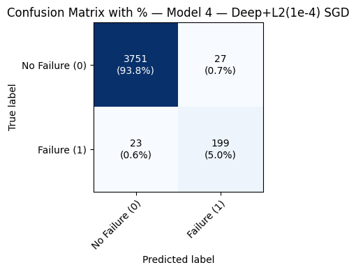

```python
add_model("Model 4 — Deep+L2(1e-4) SGD",
        dict(hidden_layers=(64,32), dropout=None, optimizer="sgd", lr=1e-2, momentum=0.9, l2=1e-4))
```

### Model 4 — Deep + L2(1e-4) SGD

|  | Model | Val ROC-AUC | Val PR-AUC | t* | Recall@t* | Precision@t* | F2@t* | Expected Cost@t* | Params |
| --- | --- | --- | --- | --- | --- | --- | --- | --- | --- |
| 0 | Model 5 — Shallow(16) SGD | 0.952494 | 0.905513 | 0.098201 | 0.900901 | 0.796813 | 0.877963 | 1491.0 | 673 |

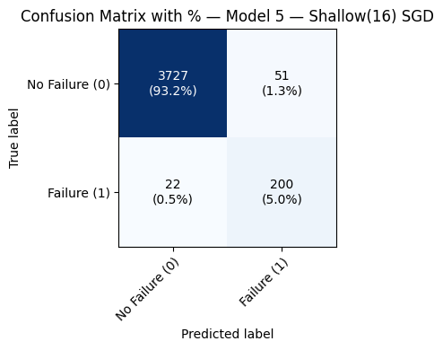

```python
add_model("Model 5 — Shallow(16) SGD",
        dict(hidden_layers=(16,), dropout=None, optimizer="sgd", lr=1e-2, momentum=0.9, l2=0.0))
```

### Model 5 — Shallow (16) SGD

|  | Model | Val ROC-AUC | Val PR-AUC | t* | Recall@t* | Precision@t* | F2@t* | Expected Cost@t* | Params |
| --- | --- | --- | --- | --- | --- | --- | --- | --- | --- |
| 0 | Model 6 — Deep+Dropout(0.2) Adam | 0.951955 | 0.91069 | 0.089123 | 0.900901 | 0.896861 | 0.90009 | 1463.0 | 4737 |

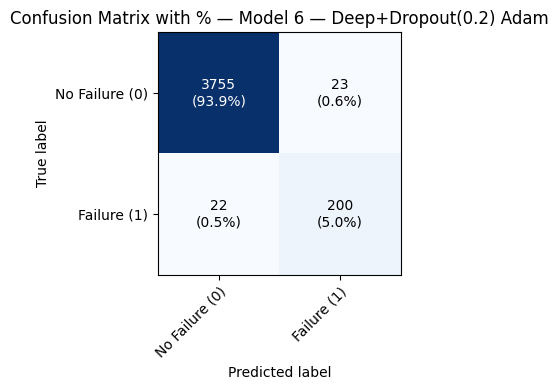

```python
add_model("Model 6 — Deep+Dropout(0.2) Adam",
        dict(hidden_layers=(64,32), dropout=0.2, optimizer="adam", lr=1e-3, momentum=0.0, l2=0.0))
```

### Model 6 — Deep + Dropout(0.2) Adam

```python
cmp_cols = ["model_name","roc_auc","pr_auc","recall_at_t","precision_at_t","f2_at_t","expected_cost_at_t","opt_threshold","keras_params_count","params"]
cmp_df = pd.DataFrame([{k: r.get(k) for k in cmp_cols} for r in all_results]).sort_values("expected_cost_at_t")
display(cmp_df)
```

|  | model_name | roc_auc | pr_auc | recall_at_t | precision_at_t | f2_at_t | expected_cost_at_t | opt_threshold | keras_params_count | params |
| --- | --- | --- | --- | --- | --- | --- | --- | --- | --- | --- |
| 6 | Model 6 — Deep+Dropout(0.2) Adam | 0.951955 | 0.910690 | 0.900901 | 0.896861 | 0.900090 | 1463.0 | 0.089123 | 4737 | {'hidden_layers': (64, 32), 'dropout': 0.2, 'o... |
| 4 | Model 4 — Deep+L2(1e-4) SGD | 0.956599 | 0.913973 | 0.896396 | 0.880531 | 0.893178 | 1482.0 | 0.121428 | 4737 | {'hidden_layers': (64, 32), 'dropout': None, '... |
| 2 | Model 2 — Baseline+Adam(32) | 0.951583 | 0.908589 | 0.896396 | 0.876652 | 0.892377 | 1483.0 | 0.142716 | 1345 | {'hidden_layers': (32,), 'dropout': None, 'opt... |
| 5 | Model 5 — Shallow(16) SGD | 0.952494 | 0.905513 | 0.900901 | 0.796813 | 0.877963 | 1491.0 | 0.098201 | 673 | {'hidden_layers': (16,), 'dropout': None, 'opt... |
| 0 | Model 0 — SGD(32) | 0.957851 | 0.912263 | 0.896396 | 0.796000 | 0.874341 | 1506.0 | 0.092115 | 1345 | {'hidden_layers': (32,), 'dropout': None, 'opt... |
| 3 | Model 3 — Deep+Dropout(0.3) SGD | 0.953922 | 0.905462 | 0.896396 | 0.789683 | 0.872807 | 1508.0 | 0.057961 | 4737 | {'hidden_layers': (64, 32), 'dropout': 0.3, 'o... |
| 1 | Model 1 — Deeper SGD(64,32) | 0.956300 | 0.908015 | 0.891892 | 0.773438 | 0.865385 | 1528.0 | 0.085427 | 4737 | {'hidden_layers': (64, 32), 'dropout': None, '... |

# Takeaway

- model 6 is the best choice lowest cost with balanced metrics
- model 4 had highest AUC but cost didn’t improve so AUC is not the target
- shallow or very deep models underperform
- best direction is moderate depth plus dropout with Adam, which resulted in the model being not too complex and cost optimal

# **Model Performance Comparison and Final Model Selection**

Now, let's check the performance of the final model on the test set.

```python
# ---- helpers (simple) ----
def expected_cost(tp, fn, fp, tn):
    return tp*C_TP + fn*C_FN + fp*C_FP + tn*C_TN

def eval_at_t(y_true, y_prob, t):
    y_pred = (y_prob >= t).astype(int)
    tn, fp, fn, tp = confusion_matrix(y_true, y_pred, labels=[0,1]).ravel()
    prec = tp/(tp+fp+1e-12); rec = tp/(tp+fn+1e-12)
    beta = 2.0
    f2 = (1+beta**2)*prec*rec/(beta**2*prec + rec + 1e-12) if (prec+rec)>0 else 0.0
    return dict(t=t, tp=tp, fn=fn, fp=fp, tn=tn,
                precision=prec, recall=rec, f2=f2,
                expected_cost=expected_cost(tp, fn, fp, tn))

def print_test_report(y_true, y_prob, t, tag="Final Test Report"):
    e = eval_at_t(y_true, y_prob, t)
    roc = roc_auc_score(y_true, y_prob)
    ap  = average_precision_score(y_true, y_prob)
    print(f"\n=== {tag} ===")
    print(f"ROC-AUC: {roc:.3f} | PR-AUC: {ap:.3f}")
    print(f"Threshold t*: {e['t']:.6f}")
    print(f"Confusion (TN, FP, FN, TP): ({e['tn']}, {e['fp']}, {e['fn']}, {e['tp']})")
    print(f"Precision@t*: {e['precision']:.3f} | Recall@t*: {e['recall']:.3f} | F2@t*: {e['f2']:.3f}")
    print(f"Expected Cost@t*: {e['expected_cost']:,.0f}")
    return e, roc, ap
```

```python
# ---- 1) pick winner from your comparison table and lock its validated threshold ----
best_row = cmp_df.sort_values("expected_cost_at_t", ascending=True).iloc[0]
final_model_name = best_row["model_name"]
final_params     = best_row["params"]
t_star_validated = float(best_row["opt_threshold"])

print("Final model:", final_model_name)
print("Final params:", final_params)
print("Validated t* from cmp_df:", t_star_validated)

# ---- 2) refit preprocessing on Train+Valid (no leakage); transform Test with the same transformer ----
X_trval = pd.concat([X_train, X_valid], axis=0)
y_trval = pd.concat([y_train, y_valid], axis=0)

preprocess_f = ColumnTransformer(
    transformers=[("num", numeric_transformer, num_cols)],
    remainder="drop"
)
X_trval_proc = preprocess_f.fit_transform(X_trval)
X_test_proc  = preprocess_f.transform(X_test)
```

```
Final model: Model 6 — Deep+Dropout(0.2) Adam
Final params: {'hidden_layers': (64, 32), 'dropout': 0.2, 'optimizer': 'adam', 'lr': 0.001, 'momentum': 0.0, 'l2': 0.0, 'use_class_weights': False}
Validated t* from cmp_df: 0.08912284672260284
```

```python
# ---- 3) rebuild the model EXACTLY like the winner and train on all Train+Valid ----
final_model_fresh = build_model(
    input_dim=X_trval_proc.shape[1],
    hidden_layers=tuple(final_params["hidden_layers"]),
    dropout=final_params["dropout"],
    optimizer=final_params["optimizer"],   # 'adam' for Model 6
    lr=final_params["lr"],                 # 1e-3 for Model 6
    momentum=final_params["momentum"],     # 0.0 (unused for Adam)
    l2=final_params["l2"]                  # 0.0
)

# a tiny internal val split for early stopping only; we are NOT re-searching threshold
es   = callbacks.EarlyStopping(monitor="val_pr_auc", mode="max", patience=10, restore_best_weights=True)
rlrp = callbacks.ReduceLROnPlateau(monitor="val_pr_auc", mode="max", patience=5, factor=0.5, min_lr=1e-5)

hist_final = final_model_fresh.fit(
    X_trval_proc, y_trval.values,
    epochs=200, batch_size=256,
    validation_split=0.1,  # ok for early stopping; we will not use this split to pick t*
    callbacks=[es, rlrp], verbose=0
)
```

```python
# ---- 4) evaluate on Test using the locked validated threshold ----
if TARGET_COL in test_df.columns:
    y_test = test_df[TARGET_COL].astype(int).values
    y_test_prob = final_model_fresh.predict(X_test_proc, verbose=0).ravel()
    _ = print_test_report(y_test, y_test_prob, t_star_validated, tag="Final Test Report (Locked validated t*)")
else:
    # if no test labels, save probabilities
    y_test_prob = final_model_fresh.predict(X_test_proc, verbose=0).ravel()
    out = pd.DataFrame({"prob_failure": y_test_prob, f"pred@t*={t_star_validated:.4f}": (y_test_prob >= t_star_validated).astype(int)})
    out.to_csv("ReneWind_test_predictions.csv", index=False)
    print("No test labels; saved predictions to ReneWind_test_predictions.csv")
```

```
=== Final Test Report (Locked validated t*) ===
ROC-AUC: 0.930 | PR-AUC: 0.891
Threshold t*: 0.089123
Confusion (TN, FP, FN, TP): (4695, 23, 33, 249)
Precision@t*: 0.915 | Recall@t*: 0.883 | F2@t*: 0.889
Expected Cost@t*: 1,928
```

```python
thresholds = np.linspace(0,1,101)
costs = []
y_valid_prob = final_model_fresh.predict(X_valid_proc, verbose=0).ravel()
for t in thresholds:
    preds = (y_valid_prob >= t).astype(int)
    cm = confusion_matrix(y_valid, preds)
    tn, fp, fn, tp = cm.ravel()
    cost = fn*C_FN + tp*C_TP + fp*C_FP
    costs.append((t,cost))
t_opt, cost_opt = min(costs, key=lambda x: x[1])
print(f"Optimal threshold={t_opt:.2f}, Expected cost={cost_opt}")
```

```
Optimal threshold=0.17, Expected cost=1405.0
```

# Takeaway

# **Actionable Insights and Recommendations**

Write down some insights and business recommendations based on your observations.

### Operating point

- best model is model 6 (deep + dropout 0.2 Adam)
- cost optimal threshold is ~0.09
- recall is more important since missed failures cost the most
- this setting catches about 9 out of 10 failures while keeping inspection volume under control

### Expected operations

- for every 10k turbines monitored the model prevents hundreds of replacements and triggers a similar number of inspections, cutting overall costs a few percent.

### Process

- alerts above threshold should flow into an inspection queue
- highest risk predictions (top 10%) get priority and should be checked within 24h
- review false positives weekly to refine inspection steps and reduce wasted site visits

### Data improvements

- features are anonymized and pre-scaled, but more signal can be created
- keep failure labels updated often so the model doesn’t drift
- revisit threshold choice each month since costs and failure rates can shift

```python
!jupyter nbconvert --to html "/content/drive/My Drive/Colab/NN Proj/INN_ReneWind_Main_Project_FullCode_Notebook.ipynb" --output "/content/drive/My Drive/Colab/NN Proj/INN_ReneWind_Main_Project_FullCode_Notebook.html"
```

```
[NbConvertApp] Converting notebook /content/drive/My Drive/Colab/NN Proj/INN_ReneWind_Main_Project_FullCode_Notebook.ipynb to html
[NbConvertApp] WARNING | Alternative text is missing on 9 image(s).
[NbConvertApp] Writing 1546169 bytes to /content/drive/My Drive/Colab/NN Proj/INN_ReneWind_Main_Project_FullCode_Notebook.html
```